# Assignment 2: Power Poles & Catenary Curves

Programming for Engineers (ENGG1001)  
**Due: 22 May 2026, 15:00 GMT+10**

Published

May 12, 2026

# Introduction

## Aim

The aim of this assignment is to synthesise your understanding of *NumPy* `ndarrays`, visualisation with *matplotlib*, and object-oriented programming. You will apply these in an engineering problem, namely the analysis of an overhead power line installation similar to that shown in Figure 1. Your solutions are to be formally implemented in *Python*, using the functionality covered in lectures.

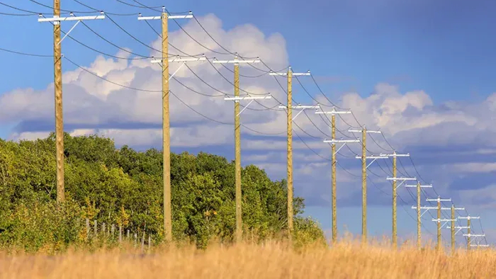

Figure 1: A power distribution line, in which six electricity cables and one communications cable are connected to a linear array of poles (Bentley 2026).

## Learning Objectives

This assignment supports the following learning objectives, as listed in the Electronic Course Profile:

1. Differentiate and apply program constructs such as variables, selection, iteration and sub-routines.
2. Recognise and apply basic object-oriented design methodologies, along with associated concepts such as classes, instances and methods.
3. Interpret an engineering problem and design an algorithmic solution to the problem.
4. Apply techniques for program testing and debugging.
5. Apply sound programming techniques to the solution of real world engineering problems.
6. Analyse and visualise engineering data.

## Background

Overhead power lines are central to the transmission and distribution of electrical power. In a country the size of Australia, they represent critical infrastructure that link renewable (e.g. large-scale solar PV arrays, wind turbines) and non-renewable (e.g. coal-fired turbines) sources of electricity with storage (e.g. pumped hydroelectricity) over very large distances.

The consequences of power line failure can be significant. In 2016, extreme weather contributed to the collapse of more than 20 transmission line towers (see Figure 2), which in turn resulted in a blackout in most of the state of South Australia. During cyclones and severe storms, falling trees can break power lines, leaving them *live* and at ground level. Inadequate clearance can result in the interaction of power lines with heavy equipment (e.g. cranes, excavators), resulting in serious injury or death. Designing a power line with adequate ground clearance is a central component of this assignment.

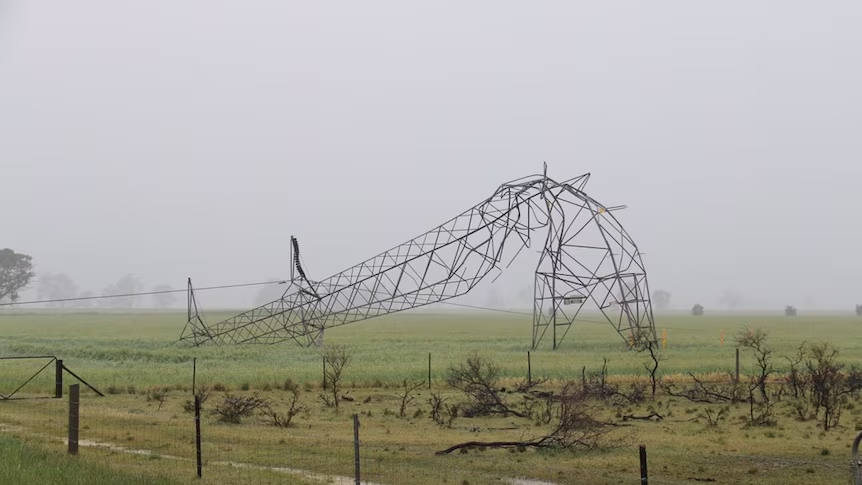

Figure 2: A collapsed transmission line tower in mid-north South Australia, which contributed to a statewide blackout in 2016 (ABC News 2021).

The characteristic shape of a power line is described by a function called a *catenary* curve. We will build it up in two steps: first the *raw* curve (which gives the underlying shape of the cable), and then the *scaled* curve (which shifts that shape so the cable ends sit on top of the poles).

### Raw catenary

The raw catenary is defined in a local coordinate system where $x = 0$ sits directly below the lowest point of the cable. Its equation is given by Equation 1:

$$y_r(x) = \text{scale} \cdot \cosh\!\left(\frac{x}{\text{scale}}\right),
\tag{1}$$

where the *scale* parameter is:

$$\text{scale} = \frac{\text{tension}}{\text{weight}},$$

and:

- $x$ is the horizontal distance along the cable measured from the midpoint between the two poles. It ranges from $-\text{span}/2$ (left pole) to $+\text{span}/2$ (right pole).
- $\text{span} = x_R - x_L$ is the horizontal distance between the two poles.
- $x_L$ and $x_R$ are the x coordinates of the left and right poles respectively, measured in the global coordinate system (in metres).
- $\text{tension}$ is the tension in the cable (in Newtons).
- $\text{weight}$ is the weight per unit length of the cable (in Newtons per metre). Note that wherever we refer to weight in this assignment, we are referring to the weight per unit length of the cable.

### Scaled catenary

Equation 1 correctly describes the *shape* of the cable, but the ends of the raw curve sit at $y_r(\pm\text{span}/2)$ — not at the height of the poles. To make the cable ends meet the tops of the poles (which are both at height $\text{height}$), we shift the raw curve vertically. This gives the *scaled* catenary in Equation 2:

$$y_s(x) = y_r(x) - y_r(-\text{span}/2) + \text{height},
\tag{2}$$

where:

- $x$ is still the horizontal distance measured from the midpoint between the poles, with $x \in [-\text{span}/2,\, \text{span}/2]$.
- $y_s(x)$ is the height of the cable at horizontal distance $x$ (in metres).
- $y_r(-\text{span}/2)$ is the value of the raw catenary at the left pole. Because $\cosh$ is symmetric, this is also equal to $y_r(+\text{span}/2)$, so subtracting this term anchors *both* ends of the cable at $y = \text{height}$.
- $\text{height}$ is the height of the poles that the cable connects to (in metres). Both poles are assumed to be the same height.

To plot the cable against the global pole positions, the horizontal coordinate $x$ is shifted by the midpoint $(x_L + x_R)/2$ — this maps the cable endpoints from $\pm\text{span}/2$ onto $x_L$ and $x_R$.

## The Problem

You have been provided with a file that contains data related to a short power line. It includes the ID and *easting* (i.e. distance in metres in the east-west direction, as measured from a reference point) of each pole. For the purposes of these tasks, you can assume that:

- The power line is installed on perfectly flat terrain.
- Poles are connected to one another by a single cable that is fitted to the top of the poles (which are all the same height).
- The left pole is the pole with the smaller easting value, and the right pole is the pole with the larger easting value.

Your task is to calculate and visualise the shape of each cable in this power line and then determine the line tension required to ensure a minimum safe ground clearance. You will do these things using both procedural and object-oriented programming.

## Restrictions

You must use only the libraries that we have taught you in this course: namely `NumPy` and `matplotlib`. You are not allowed to use any other libraries. If you use other libraries, then the autograder will not be able to run your code and you will receive a mark of zero for the assignment.

## Starter Code

You are provided with a starter code file, `a2.py` which you are expected to write your code in.

```
a2.py
```

```python
import numpy as np
import matplotlib.pyplot as plt

__author__ = "<your name here>"
__email__ = "<your email here>"
__date__ = "<date here>"

GRAVITY = 9.81  # m/s^2

# Write your code down below!



if __name__ == "__main__":
    # You can use this section to test your code as you write it.
    pass
```

Here is also a data file, `pole_data.csv`, which contains data for the poles that the cables connect to. You will find this file useful for Parts B and C of the assignment. Note that `P_ID` refers to the pole ID, and `ESTG` (aka Easting) refers to the easting coordinate of the pole.

```
pole_data.csv
```

```
P_ID,ESTG
0,20000
1,20050
2,20130
3,20160
... (13 more lines)
```

# Part A: Operations on a Single Cable

## Task 1 (0.5 marks)

Write a function `raw_catenary()` that calculates the raw, unscaled catenary curve y coordinate, for a given x coordinate, tension, weight. The function signature is as follows:

```python
def raw_catenary(x_coord: float, tension: float, mass: float) -> float:
```

An example usage of the functionn is shown below:

```python
x_coord = 5.0
tension = 1000.0
mass = 0.5
y_coord = raw_catenary(x_coord, tension, mass)
print(f"The y coordinate of the unscaled catenary at x = {x_coord} is: {y_coord}")
```

Output

```
The y coordinate of the unscaled catenary at x = 5.0 is: 203.93491394223736
```

**Important**

For this function, `x_coord` is assumed to be within the range of `-span/2 to span/2`.

Notice that the function uses the variable `mass` (which represents the mass per unit length of the cable in kg/m) instead of `weight` in its signature. How can you calculate the weight from the mass?

## Task 2 (0.5 marks)

Write a function `cable_catenary()` that calculates the scaled catenary curve and returns two arrays, one for the x coordinates and one for the y coordinates. The function should accept the following parameters below as shown below:

```python
def cable_catenary(left_pole: float, right_pole: float, tension: float,
                    mass: float, height: float, num_points: int) -> tuple[np.ndarray, np.ndarray]:
```

An example usage of the function is shown below:

```python
left_pole = 0.0
right_pole = 100.0
tension = 2500.0
mass = 0.5
height = 10.0
num_points = 50
x_coords, y_coords = cable_catenary(left_pole, right_pole, tension,
                                     mass, height, num_points)
print(f"Scaled catenary x coordinates: {x_coords}")
print(f"Scaled catenary y coordinates: {y_coords}")
```

Output

```
Scaled catenary x coordinates: [  0.           2.04081633   4.08163265   6.12244898   8.16326531
  10.20408163  12.24489796  14.28571429  16.32653061  18.36734694
  20.40816327  22.44897959  24.48979592  26.53061224  28.57142857
  30.6122449   32.65306122  34.69387755  36.73469388  38.7755102
  40.81632653  42.85714286  44.89795918  46.93877551  48.97959184
  51.02040816  53.06122449  55.10204082  57.14285714  59.18367347
  61.2244898   63.26530612  65.30612245  67.34693878  69.3877551
  71.42857143  73.46938776  75.51020408  77.55102041  79.59183673
  81.63265306  83.67346939  85.71428571  87.75510204  89.79591837
  91.83673469  93.87755102  95.91836735  97.95918367 100.        ]
Scaled catenary y coordinates: [10.          9.80357959  9.61536699  9.43535919  9.26355328  9.09994653
  8.94453631  8.79732012  8.65829561  8.52746054  8.40481282  8.29035049
  8.1840717   8.08597476  7.99605808  7.91432024  7.84075992  7.77537593
  7.71816724  7.66913292  7.62827218  7.59558438  7.57106899  7.55472562
  7.54655399  7.54655399  7.55472562  7.57106899  7.59558438  7.62827218
  7.66913292  7.71816724  7.77537593  7.84075992  7.91432024  7.99605808
  8.08597476  8.1840717   8.29035049  8.40481282  8.52746054  8.65829561
  8.79732012  8.94453631  9.09994653  9.26355328  9.43535919  9.61536699
  9.80357959 10.        ]
```

**Tip**

You can use the function you defined in Task 1 here. Consider the catenary curve equation we provide to you initially, what is missing between that and the task 1 version?

Recall the domain of the function `raw_catenary`, does it differ to the range of the x coordinates for `cable_catenary`? Note that this function is required to return the x coordinates transformed to the range of `left_pole` to `right_pole`.

## Task 3 (1 mark)

Write a function `plot_catenary()` that plots the catenary curve for the given parameters. In addition to the plot, the function should also plot the poles that the cable connects to. The function should accept the following parameters as shown below:

```python
def plot_catenary(left_pole: float, right_pole: float, tension: float,
                   mass: float, height: float, num_points: int) -> None:
```

An example usage of the function is shown below:

```python
left_pole = 0.0
right_pole = 100.0
tension = 2500.0
mass = 0.5
height = 10.0
num_points = 50
plot_catenary(left_pole, right_pole, tension, mass, height, num_points)
```

Output

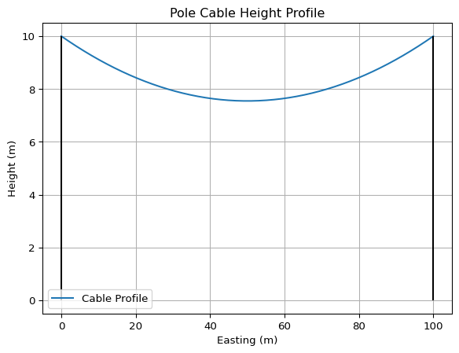

**Tip**

To plot the poles, the function `ax.vlines()` may be of use.

## Task 4 (1 mark)

Write a function `calc_clearance()` that calculates the minimum clearance of the cable from the ground. The function should accept the following parameters as shown below:

```python
def calc_clearance(left_pole: float, right_pole: float,
                   tension: float, mass: float, height: float) -> float:
```

An example usage of the function is shown below:

```python
left_pole = 0.0
right_pole = 100.0
tension = 2500.0
mass = 0.5
height = 10.0
clearance = calc_clearance(left_pole, right_pole, tension, mass, height)
print(f"The minimum clearance of the cable from the ground is: {clearance} m")
```

Output

```
The minimum clearance of the cable from the ground is: 7.5455325436658995 m
```

**Tip**

There are two main ways to approach this problem. The code from either task 1 or 2 could be of help here.

## Task 5 (2 marks)

Write a function `determine_min_cable_tension()` that determines the minimum tension required to achieve a desired clearance. The function should accept the following parameters as shown below:

```python
def determine_min_cable_tension(left_pole: float, right_pole: float, mass: float,
                          height: float, desired_clearance: float) -> float:
```

An example usage of the function is shown below:

```python
left_pole = 0.0
right_pole = 100.0
mass = 0.5
height = 10.0
desired_clearance = 9.0
min_tension = determine_min_cable_tension(left_pole, right_pole, mass,
                                   height, desired_clearance)
print(f"The minimum tension required to achieve a clearance of {desired_clearance} m is: {min_tension} N")
```

Output

```
The minimum tension required to achieve a clearance of 9.0 m is: 6132.0673252339475 N
```

**Tip**

There is no analytical solution to this problem, so you will need to use a numerical method to solve it. A simple approach is to use a “guess and check” method, where you start with an initial guess for the tension and then keep on adding a small amount to the tension until you achieve the desired clearance. There are some more efficient numerical methods, but you will need to do some research to find out about them.

The accuracy of your solution should be within 0.1 N of the actual minimum tension required to achieve the desired clearance.

# Part B: Operations on a Line of Cables

## Task 6 (1 mark)

Write a function `load_poles()` that loads pole data from a csv file and returns an array of the headers of the csv file as **strings**, a 1d array of the pole IDs as **integers**, and a 1d array of the pole coordinates as **floats**. The function should accept the following parameter as shown below:

```python
def load_poles(file_path: str) -> tuple[np.ndarray, np.ndarray, np.ndarray]:
```

An example usage of the function is shown below:

```python
file_path = "pole_data.csv"
headers, pole_ids, pole_coords = load_poles(file_path)
print(f"Headers: {headers}")
print(f"Pole IDs: {pole_ids}")
print(f"Pole coordinates: {pole_coords}")
```

Output

```
Headers: ['P_ID' 'ESTG']
Pole IDs: [ 0  1  2  3  4  5  6  7  8 77 10 11 12 13 14 15]
Pole coordinates: [20000. 20050. 20130. 20160. 20210. 20310. 20350. 20400. 20470. 20500.
 20560. 20650. 20710. 20770. 20820. 20900.]
```

## Task 7 (1 mark)

Write a function `plot_line()` that plots a line of cables given the pole data and the parameters of the cables. The function should accept the following parameters as shown below:

```python
def plot_line(pole_coords: np.ndarray, tension: float, mass: float,
              height: float, num_points_cable: int) -> None:
```

An example usage of the function is shown below:

```python
headers, pole_ids, pole_coords = load_poles("pole_data.csv")
tension = 2500.0
mass = 0.5
height = 10.0
num_points_cable = 50
plot_line(pole_coords, tension, mass, height, num_points_cable)
```

Output

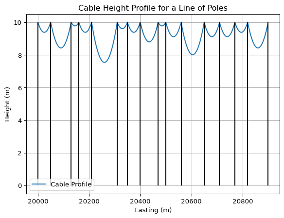

**Tip**

The parameter `num_points_cable` refers to the number of points that should be used to plot each cable. You should ensure that you concatenate all the cable x and y coordinates together before plotting.

## Task 8 (2 marks)

Write a function `min_line_tension()` that determines the overall minimum tension required to achieve a desired clearance for a line of cables. This function additionally returns the ids of the poles between which the minimum clearance occurs. For this problem, you should assume that all the cables in the line have the same tension. The function should accept the following parameters as shown below:

```python
def min_line_tension(pole_ids: np.ndarray, pole_coords: np.ndarray,
                     mass: float, height: float, desired_clearance: float) \
                        -> tuple[float, int, int]:
```

An example usage of the function is shown below:

```python
headers, pole_ids, pole_coords = load_poles("pole_data.csv")
mass = 0.5
height = 10.0
desired_clearance = 9.0
tension, left_pole_id, right_pole_id = min_line_tension(pole_ids, pole_coords, mass,
                                                        height, desired_clearance)
print(f"The tension required to achieve a clearance of {desired_clearance} m is: {tension} N")
print(f"The clearance occurs between pole {left_pole_id} and pole {right_pole_id}")
```

Output

```
The tension required to achieve a clearance of 9.0 m is: 6132.0673252339475 N
The clearance occurs between pole 4 and pole 5
```

**Tip**

What is the difference between finding the minimum tension for a single cable and finding the minimum tension for a line of cables? Can the function you wrote for Task 5 be used here?

The accuracy of your solution should be within 0.1 N of the actual minimum tension required to achieve the desired clearance.

# Part C: Representing Cables as Objects

For the rest of this assignment, we will now *mostly* leave behind numpy and focus on using classes to represent our cables. The functions that you wrote for previous tasks will still be of use here.

## Task 9 (1 mark)

Write a class `Cable` that represents a cable. The class is expected to privately store the following attributes:

- `id`: the id of the cable, which serves as an identifier for each cable.
- `left_pole`: the x coordinate of the left pole that the cable connects to
- `right_pole`: the x coordinate of the right pole that the cable connects to
- `tension`: the tension of the cable
- `mass`: the mass per unit length of the cable
- `height`: the height of the poles that the cable connects to

The class should have the following methods:

- `__init__(self, id: str, left_pole: float, right_pole: float, tension: float,` `mass: float, height: float)`: the constructor method that initialises the attributes of the class.
- `get_left_pole(self)`: a getter method that returns the x coordinate of the left pole
- `get_right_pole(self)`: a getter method that returns the x coordinate of the right pole
- `get_tension(self)`: a getter method that returns the tension of the cable
- `get_mass(self)`: a getter method that returns the mass per unit length of the cable
- `get_height(self)`: a getter method that returns the height of the poles that the cable
- `get_id(self)`: a method that returns the id of the cable.
- `set_tension(self, tension: float)`: a setter method that sets the tension of the cable to a new value.

Here is an example of how the class can be used:

```python
cable = Cable("Cable 1", 0.0, 100.0, 2500.0, 0.5, 10.0)
print(f"Cable ID: {cable.get_id()}")
print(f"Left pole x coordinate: {cable.get_left_pole()}")
print(f"Right pole x coordinate: {cable.get_right_pole()}")
print(f"Tension: {cable.get_tension()} N")
print(f"Mass per unit length: {cable.get_mass()} kg/m")
print(f"Height of poles: {cable.get_height()} m")

cable.set_tension(3000.0)
print(f"New tension: {cable.get_tension()} N")
```

Output

```
Cable ID: Cable 1
Left pole x coordinate: 0.0
Right pole x coordinate: 100.0
Tension: 2500.0 N
Mass per unit length: 0.5 kg/m
Height of poles: 10.0 m
New tension: 3000.0 N
```

## Task 10 (2 marks)

Write the following additional methods to extend the functionality of the `Cable` class:

- `calc_clearance(self)`: a method that calculates the minimum clearance of the cable from the ground.
- `plot(self, num_points: int)`: a method that plots the cable using the parameters of the cable and the number of points specified. The method should also plot the poles that the cable connects to.
- `update_min_tension(self, desired_clearance: float)`: a method that determines the minimum tension required to achieve a desired clearance for the cable and updates the tension attribute of the cable to this new value.
- `cable_coordinates(self, num_points: int)`: a method that returns the x and y coordinates of the cable for the given number of points.
- `calc_span(self)`: a method that calculates the span of the cable.
- `calc_length(self)`: a method that calculates the length of the cable.

**Tip**

The length of the cable is defined by the following equation:

$$\text{Length} = 2 * \text{scale} * \sinh\left(\frac{\text{span}}{2 * \text{scale}}\right)$$

where $\text{scale} = \frac{\text{tension}}{\text{weight}}$

Here is an example of how these methods can be used:

```python
cable = Cable("Cable 1", 0.0, 100.0, 2500.0, 0.5, 10.0)
clearance = cable.calc_clearance()
print(f"Minimum clearance from the ground: {clearance} m")

cable.update_min_tension(9.0)
print(f"Updated tension to achieve a clearance of 9.0 m: {cable.get_tension()} N")

x_coords, y_coords = cable.cable_coordinates(50)
print(f"Cable x coordinates: {x_coords}")
print(f"Cable y coordinates: {y_coords}")

span = cable.calc_span()
print(f"Span of the cable: {span} m")
length = cable.calc_length()
print(f"Length of the cable: {length} m")

cable.plot(50)
```

Output

```
Minimum clearance from the ground: 7.5455325436658995 m
Updated tension to achieve a clearance of 9.0 m: 6132.0673252339475 N
Cable x coordinates: [  0.           2.04081633   4.08163265   6.12244898   8.16326531
  10.20408163  12.24489796  14.28571429  16.32653061  18.36734694
  20.40816327  22.44897959  24.48979592  26.53061224  28.57142857
  30.6122449   32.65306122  34.69387755  36.73469388  38.7755102
  40.81632653  42.85714286  44.89795918  46.93877551  48.97959184
  51.02040816  53.06122449  55.10204082  57.14285714  59.18367347
  61.2244898   63.26530612  65.30612245  67.34693878  69.3877551
  71.42857143  73.46938776  75.51020408  77.55102041  79.59183673
  81.63265306  83.67346939  85.71428571  87.75510204  89.79591837
  91.83673469  93.87755102  95.91836735  97.95918367 100.        ]
Cable y coordinates: [10.          9.92002351  9.84338098  9.77007219  9.70009696  9.6334551
  9.57014643  9.51017077  9.45352798  9.4002179   9.35024039  9.30359531
  9.26028254  9.22030197  9.18365348  9.15033699  9.1203524   9.09369963
  9.07037862  9.05038929  9.0337316   9.0204055   9.01041095  9.00374794
  9.00041644  9.00041644  9.00374794  9.01041095  9.0204055   9.0337316
  9.05038929  9.07037862  9.09369963  9.1203524   9.15033699  9.18365348
  9.22030197  9.26028254  9.30359531  9.35024039  9.4002179   9.45352798
  9.51017077  9.57014643  9.6334551   9.70009696  9.77007219  9.84338098
  9.92002351 10.        ]
Span of the cable: 100.0 m
Length of the cable: 100.02666169077452 m
```

Output

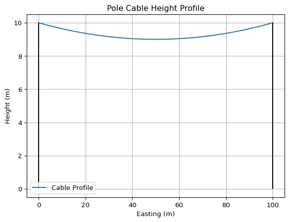

## Task 11 (1 mark)

Write a function `create_cables()` that returns a list of `Cable` objects created from the pole data in the csv file. Each Cable is to have an id based upon the pole IDs that is is connected to. This ID is to be stored as `"Cable: {left_pole_id}-{right_pole_id}"` The function should accept the following parameters as shown below:

```python
def create_cables(file_path: str, tension: float,
                  mass: float, height: float) -> list[Cable]:
```

An example usage of the function is shown below:

```python
file_path = "pole_data.csv"
tension = 2500.0
mass = 0.5
height = 10.0
cables = create_cables(file_path, tension, mass, height)
print(f"Cable ID: {cables[0].get_id()}")
print(f"Left pole x coordinate: {cables[0].get_left_pole()}")
print(f"Right pole x coordinate: {cables[0].get_right_pole()}")
print(f"Tension: {cables[0].get_tension()} N")
print(f"Mass per unit length: {cables[0].get_mass()} kg/m")
print(f"Height of poles: {cables[0].get_height()} m")
```

Output

```
Cable ID: Cable: 0-1
Left pole x coordinate: 20000.0
Right pole x coordinate: 20050.0
Tension: 2500.0 N
Mass per unit length: 0.5 kg/m
Height of poles: 10.0 m
```

## Task 12 (2 marks)

Write a class `Line` which stores a set of `Cable` objects and has the following methods:

- `__init__(self, cables: list[Cable])`: the constructor method that initialises the attributes of the class.
- `get_cable(self, id: str)`: a method that returns the `Cable` object with the given id. If the id does not correspond to any cable in the line, the method should return `None`.
- `plot(self, num_points_cable: int)`: a method that plots the line of cables using the `cable_coordinates()` method of the `Cable` class and the number of points specified for each cable. You should ensure that each cable is labelled with its id in the plot.
- `min_line_tension(self, desired_clearance: float)`: a method that determines the overall minimum tension required to achieve a desired clearance for the line of cables and updates the tension of each cable in the line to this new value. This method should also return the coordinates of the poles between which the minimum clearance occurs.

An example usage of the class is shown below:

```python
cables = create_cables("pole_data.csv", 2500.0, 0.5, 10.0)
line = Line(cables)

# grabbing the correct cable
cable = line.get_cable("Cable: 0-1")
print(f"Cable ID: {cable.get_id()}")

tension, left_pole, right_pole = line.min_line_tension(9.0)
print(f"Minimum tension for line of poles with desired clearance of 9.0 = {tension}")
print(f"Minimum tension determined by poles {left_pole} and {right_pole}")

# this shows that the tension of the cable has been updated
cable = line.get_cable("Cable: 0-1")
print(f"Updated tension for {cable.get_id()}: {cable.get_tension()} N")
clearance = cable.calc_clearance()
print(f"Updated clearance for {cable.get_id()}: {clearance} m")

# plotting the line of cables
line.plot(50)
```

Output

```
Cable ID: Cable: 0-1
Minimum tension for line of poles with desired clearance of 9.0 = 6132.0673252339475
Minimum tension determined by poles 20210.0 and 20310.0
Updated tension for Cable: 0-1: 6132.0673252339475 N
Updated clearance for Cable: 0-1: 9.750024991652708 m
```

Output

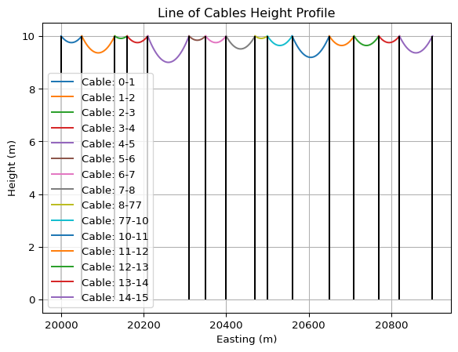

**Tip**

When you are plotting the line of cables, you should ensure that each cable is labelled with its id in the plot. Additionally, you do not need to manually colour the cables, as you can let matplotlib automatically assign different colours to each cable.

The `min_line_tension()` method is a bit more complex than the `determine_min_cable_tension()` function you wrote for Task 5. Once you have determined the minimum tension required overall, you will then have to ensure that each cable in the line also matches this tension. The accuracy of your solution should be within 0.1 N of the actual minimum tension required to achieve the desired clearance.

# Writing Your Code

You must download the file, `a2.py` from above, and write your code in that file. When you submit your assignment to Gradescope you must submit only one code file and **it must be called a2.py**, also ensure that you submit the required `ai_statement.pdf` file (more details below). Do not submit any other code files or it can disrupt the automatic code testing program which will grade your assignments.

# Design

## Functionality assessment: 15 marks

The functionality will be marked out of 15. Your assignment will be put through a series of tests and your functionality mark will be automatically generated by the autograder. This grade is **NOT** overwritten. So if you have a syntax error in your code which causes it to fail all the tests even though the rest of your code is fine, you will get 0 marks.

Your final functionality mark for the assignment is based on the most recent submission. Note that functionality tests are automated and so string outputs need to exactly match what is expected. **Do not leave it until the last minute** because it generally takes time to get your code to pass the tests.

## Code Style Assessment: 5 marks

The style of your assignment will be assessed by one of the tutors, and you will be marked according to the style rubric provided below. The style mark will be out of 5.

[output not shown]

## Assignment Submission

You must submit 2 files to Gradescope: `a2.py` and `ai_statement.pdf`. You will write your code solution in `a2.py` and you will write your usage of ai statement in `ai_statement.pdf`. If you **do not submit** `ai_statement.pdf`, or if the file is **empty**, you will automatically receive **0%** for the assignment, even if your code is perfect. The autograder will clearly state whether your `ai_statement.pdf` is missing or empty, so make sure to carefully check the autograder results after you submit your assignment.

As such, even if you didn’t use ai for this assignment, you must declare that in your assignment statement. The layout of this statement is up to you, as it is not assessed directly. The following link is an official uq guidance on how to structure your ai statement: [UQ Library](https://guides.library.uq.edu.au/referencing/acknowledging-and-referencing-ai)

Requests for extensions must be made according to the guidelines in the Course Profile.

## References

ABC News. 2021. https://www.abc.net.au/news/2021-09-28/sa-statewide-blackout-anniversary-energy-impacts/100496564.

Bentley. 2026. https://it.bentley.com/software/power-line-systems/.